# Exercise Set 2: A $300 Billion Strategy

T. Evgeniou

> **IMPORTANT**: Please make sure you create a copy of this file with a customized name, so that your work (e.g. answers to the questions) is not over-written when you pull the latest content from the course github.

The purpose of this exercise is to become familiar with:

1. Some time series analysis tools;
2. Correlation matrices and principal component analysis (PCA) (see [readings of sessions 3-4](http://inseaddataanalytics.github.io/INSEADAnalytics/CourseSessions/Sessions23/FactorAnalysisReading.html));
3. More data manipulation and reporting tools (including Google Charts).

As always, while doing this exercise we will also see how to generate replicable and customizable reports. For this purpose the exercise uses the R Markdown capabilities (see [Markdown Cheat Sheet](https://www.rstudio.com/wp-content/uploads/2015/02/rmarkdown-cheatsheet.pdf) or a [basic introduction to R Markdown](http://rmarkdown.rstudio.com/authoring_basics.html)). These capabilities allow us to create dynamic reports. For example today's date is 2017-01-27 (you need to see the .Rmd to understand that this is *not* a static typed-in date but it changes every time you compile the .Rmd - if the date changed of course).

Before starting, make sure you have pulled the [exercise set 2 souce code files](https://github.com/InseadDataAnalytics/INSEADAnalytics/tree/master/Exercises/Exerciseset2) on your github repository (if you pull the course github repository you also get the exercise set files automatically). Moreover, make sure you are in the directory of this exercise. Directory paths may be complicated, and sometimes a frustrating source of problems, so it is recommended that you use these R commands to find out your current working directory and, if needed, set it where you have the main files for the specific exercise/project (there are other ways, but for now just be aware of this path issue). For example, assuming we are now in the "Data Analytics R version/INSEADAnalytics" directory, we can do these:

```r
getwd()
setwd("Exercises/Exerciseset2/")
list.files()
```

**Note:** as always, you can use the `help` command in Rstudio to find out about any R function (e.g. type `help(list.files)` to learn what the R function `list.files` does).

Let's now see the exercise.

**IMPORTANT:** You should answer all questions by simply adding your code/answers in this document through editing the file ExerciseSet2.Rmd and then clicking on the "Knit HTML" button in RStudio. Once done, please post your .Rmd and html files in your github repository.

# The Exercise: Introduction

Of course there are also many starting points for developing such a strategy (for example [this R bloggers one](http://www.r-bloggers.com/system-from-trend-following-factors/) (also on [github](https://gist.github.com/timelyportfolio/2855303)), or the [turtle traders website](http://turtletrader.com) which has many resources.

In this exercise we will develop our own strategy from scratch.

*Note (given today's market conditions):* **Prices of commodities, like oil or gold, can be excellent indicators of the health of the economy and of various industries, as we will also see below**.

# Getting the Futures Data

There are many ways to get futures data. For example, one can use the [Quandl package,](https://www.quandl.com/browse) or the [turtle traders resources,](http://turtletrader.com/hpd/) or (for INSEAD only) get data from the [INSEAD library finance data resources](http://sites.insead.edu/library/E_resources/ER_subject.cfm#Stockmarket) website. One has to pay attention on how to create continuous time series from underlying contracts with varying deliveries (e.g. see [here](https://www.quantstart.com/articles/Continuous-Futures-Contracts-for-Backtesting-Purposes) ). Using a combination of the resources above, we will use data for a number of commodities.

# Data description

Let's load the data and see what we have.

```r
suppressPackageStartupMessages(source("helpersSet2.R"))
load("data/FuturesTrendFollowingData.Rdata")
```

We have data from 2001-01-02 to 2015-09-24 of daily returns for the following 64 futures:

```r
print(colnames(futures_data))
```

```
##  [1] "Corn"               "Wheat"              "Soybeans"
##  [4] "Soybean Oil"        "Soybean Meal"       "Lean Hoggs"
##  [7] "Sugar"              "Coffee"             "Cocoa"
## [10] "Cotton"             "Canola"             "Orange Juice"
## [13] "Lumber"             "Natural Gas"        "Crude Oil"
## [16] "Brent Crude"        "Heating Oil"        "Kerosene"
## [19] "Gas Oil"            "Gasoline"           "Copper NY"
## [22] "Copper LDN"         "Silver"             "Gold"
## [25] "Platinum"           "Palladium"          "Aluminium"
## [28] "Zinc"               "Nickel"             "Treasury Bonds"
## [31] "5 yr T-Notes US"    "2 yr T-Note US"     "10yr T-Notes"
## [34] "Euro-Bund"          "Euro-Bobl"          "Euro-Schatz"
## [37] "Canadian Bond"      "JGB Japan"          "Gilts UK"
## [40] "Euroyen"            "Eurodollar"         "Euroswiss"
## [43] "Euribor"            "SP500 E-Mini"       "DAX 30"
## [46] "Eurostoxx"          "Hang Seng"          "FTSE 100 UK"
## [49] "Nasdaq 100 Mini"    "Russel 2000 E-Mini" "Dow Jones"
## [52] "TSE Toronto"        "CAC 40 France"      "OMX 30 Stockholm"
## [55] "NIKKEI 225"         "Euro"               "Norwegian Krone"
## [58] "New Zealand Dollar" "Australian Dollar"  "British Pound"
## [61] "Canadian Dollar"    "Swiss Franc"        "Japanese Yen"
## [64] "Singapore Dollar"
```

# Basic data analysis

Let's see how these are correlated. The correlation matrix is as follows:

<!--html_preserve-->

|  | Corn | Wheat | Soybeans | Soybean Oil | Soybean Meal | Lean Hoggs | Sugar | Coffee | Cocoa | Cotton | Canola | Orange Juice | Lumber | Natural Gas | Crude Oil | Brent Crude | Heating Oil | Kerosene | Gas Oil | Gasoline | Copper NY | Copper LDN | Silver | Gold | Platinum | Palladium | Aluminium | Zinc | Nickel | … |
| --- | --- | --- | --- | --- | --- | --- | --- | --- | --- | --- | --- | --- | --- | --- | --- | --- | --- | --- | --- | --- | --- | --- | --- | --- | --- | --- | --- | --- | --- | --- |
| Corn | 1.00 | 0.63 | 0.60 | 0.51 | 0.52 | 0.02 | 0.21 | 0.17 | 0.10 | 0.23 | 0.45 | 0.06 | 0.08 | 0.12 | 0.24 | 0.25 | 0.22 | 0.02 | 0.15 | 0.25 | 0.23 | 0.22 | 0.23 | 0.18 | 0.13 | 0.17 | 0.20 | 0.18 | 0.16 | … |
| Wheat | 0.63 | 1.00 | 0.45 | 0.42 | 0.39 | 0.03 | 0.20 | 0.18 | 0.09 | 0.22 | 0.38 | 0.03 | 0.07 | 0.09 | 0.21 | 0.21 | 0.18 | 0.00 | 0.12 | 0.21 | 0.21 | 0.21 | 0.20 | 0.16 | 0.12 | 0.15 | 0.17 | 0.17 | 0.14 | … |
| Soybeans | 0.60 | 0.45 | 1.00 | 0.74 | 0.84 | 0.04 | 0.20 | 0.16 | 0.12 | 0.26 | 0.64 | 0.08 | 0.08 | 0.11 | 0.27 | 0.27 | 0.25 | 0.04 | 0.18 | 0.28 | 0.28 | 0.26 | 0.24 | 0.17 | 0.17 | 0.21 | 0.23 | 0.21 | 0.18 | … |
| Soybean Oil | 0.51 | 0.42 | 0.74 | 1.00 | 0.47 | 0.04 | 0.20 | 0.18 | 0.13 | 0.28 | 0.64 | 0.10 | 0.09 | 0.13 | 0.34 | 0.34 | 0.31 | 0.09 | 0.25 | 0.37 | 0.32 | 0.30 | 0.29 | 0.23 | 0.20 | 0.24 | 0.27 | 0.25 | 0.22 | … |
| Soybean Meal | 0.52 | 0.39 | 0.84 | 0.47 | 1.00 | 0.02 | 0.16 | 0.13 | 0.09 | 0.20 | 0.51 | 0.08 | 0.07 | 0.09 | 0.17 | 0.17 | 0.16 | 0.02 | 0.11 | 0.17 | 0.20 | 0.18 | 0.17 | 0.12 | 0.12 | 0.15 | 0.16 | 0.15 | 0.13 | … |
| Lean Hoggs | 0.02 | 0.03 | 0.04 | 0.04 | 0.02 | 1.00 | 0.03 | 0.02 | 0.03 | 0.02 | 0.01 | 0.01 | 0.03 | 0.04 | 0.07 | 0.06 | 0.05 | -0.02 | 0.02 | 0.05 | 0.06 | 0.06 | 0.02 | 0.01 | 0.05 | 0.04 | 0.05 | 0.07 | 0.06 | … |
| Sugar | 0.21 | 0.20 | 0.20 | 0.20 | 0.16 | 0.03 | 1.00 | 0.22 | 0.15 | 0.19 | 0.17 | 0.06 | 0.04 | 0.07 | 0.20 | 0.19 | 0.17 | 0.02 | 0.14 | 0.19 | 0.23 | 0.21 | 0.18 | 0.13 | 0.12 | 0.16 | 0.19 | 0.18 | 0.16 | … |
| Coffee | 0.17 | 0.18 | 0.16 | 0.18 | 0.13 | 0.02 | 0.22 | 1.00 | 0.18 | 0.16 | 0.12 | 0.06 | 0.07 | 0.05 | 0.15 | 0.14 | 0.13 | 0.04 | 0.12 | 0.15 | 0.19 | 0.18 | 0.20 | 0.15 | 0.13 | 0.17 | 0.17 | 0.17 | 0.15 | … |
| Cocoa | 0.10 | 0.09 | 0.12 | 0.13 | 0.09 | 0.03 | 0.15 | 0.18 | 1.00 | 0.12 | 0.08 | 0.05 | 0.06 | 0.04 | 0.16 | 0.15 | 0.13 | 0.06 | 0.15 | 0.14 | 0.17 | 0.17 | 0.21 | 0.18 | 0.13 | 0.14 | 0.16 | 0.16 | 0.12 | … |
| Cotton | 0.23 | 0.22 | 0.26 | 0.28 | 0.20 | 0.02 | 0.19 | 0.16 | 0.12 | 1.00 | 0.22 | 0.08 | 0.07 | 0.04 | 0.20 | 0.20 | 0.18 | 0.03 | 0.16 | 0.19 | 0.23 | 0.22 | 0.17 | 0.13 | 0.10 | 0.15 | 0.19 | 0.18 | 0.18 | … |
| Canola | 0.45 | 0.38 | 0.64 | 0.64 | 0.51 | 0.01 | 0.17 | 0.12 | 0.08 | 0.22 | 1.00 | 0.06 | 0.06 | 0.06 | 0.17 | 0.19 | 0.16 | 0.03 | 0.11 | 0.21 | 0.18 | 0.16 | 0.18 | 0.13 | 0.12 | 0.15 | 0.15 | 0.14 | 0.12 | … |
| Orange Juice | 0.06 | 0.03 | 0.08 | 0.10 | 0.08 | 0.01 | 0.06 | 0.06 | 0.05 | 0.08 | 0.06 | 1.00 | 0.04 | 0.05 | 0.10 | 0.08 | 0.08 | 0.04 | 0.08 | 0.09 | 0.09 | 0.08 | 0.10 | 0.06 | 0.06 | 0.07 | 0.10 | 0.07 | 0.08 | … |
| Lumber | 0.08 | 0.07 | 0.08 | 0.09 | 0.07 | 0.03 | 0.04 | 0.07 | 0.06 | 0.07 | 0.06 | 0.04 | 1.00 | 0.00 | 0.07 | 0.07 | 0.07 | 0.04 | 0.05 | 0.09 | 0.12 | 0.11 | 0.07 | 0.02 | 0.03 | 0.06 | 0.10 | 0.08 | 0.09 | … |
| Natural Gas | 0.12 | 0.09 | 0.11 | 0.13 | 0.09 | 0.04 | 0.07 | 0.05 | 0.04 | 0.04 | 0.06 | 0.05 | 0.00 | 1.00 | 0.29 | 0.27 | 0.34 | 0.00 | 0.20 | 0.16 | 0.10 | 0.09 | 0.08 | 0.07 | 0.04 | 0.06 | 0.09 | 0.06 | 0.05 | … |
| Crude Oil | 0.24 | 0.21 | 0.27 | 0.34 | 0.17 | 0.07 | 0.20 | 0.15 | 0.16 | 0.20 | 0.17 | 0.10 | 0.07 | 0.29 | 1.00 | 0.89 | 0.84 | 0.10 | 0.56 | 0.66 | 0.37 | 0.35 | 0.29 | 0.26 | 0.20 | 0.24 | 0.30 | 0.27 | 0.25 | … |
| Brent Crude | 0.25 | 0.21 | 0.27 | 0.34 | 0.17 | 0.06 | 0.19 | 0.14 | 0.15 | 0.20 | 0.19 | 0.08 | 0.07 | 0.27 | 0.89 | 1.00 | 0.85 | 0.11 | 0.62 | 0.69 | 0.36 | 0.34 | 0.29 | 0.25 | 0.20 | 0.24 | 0.29 | 0.27 | 0.25 | … |
| Heating Oil | 0.22 | 0.18 | 0.25 | 0.31 | 0.16 | 0.05 | 0.17 | 0.13 | 0.13 | 0.18 | 0.16 | 0.08 | 0.07 | 0.34 | 0.84 | 0.85 | 1.00 | 0.10 | 0.64 | 0.63 | 0.31 | 0.30 | 0.26 | 0.23 | 0.18 | 0.21 | 0.25 | 0.24 | 0.21 | … |
| Kerosene | 0.02 | 0.00 | 0.04 | 0.09 | 0.02 | -0.02 | 0.02 | 0.04 | 0.06 | 0.03 | 0.03 | 0.04 | 0.04 | 0.00 | 0.10 | 0.11 | 0.10 | 1.00 | 0.28 | 0.10 | 0.09 | 0.10 | 0.08 | 0.05 | 0.14 | 0.15 | 0.10 | 0.08 | 0.07 | … |
| Gas Oil | 0.15 | 0.12 | 0.18 | 0.25 | 0.11 | 0.02 | 0.14 | 0.12 | 0.15 | 0.16 | 0.11 | 0.08 | 0.05 | 0.20 | 0.56 | 0.62 | 0.64 | 0.28 | 1.00 | 0.40 | 0.29 | 0.30 | 0.24 | 0.19 | 0.18 | 0.21 | 0.25 | 0.25 | 0.21 | … |
| Gasoline | 0.25 | 0.21 | 0.28 | 0.37 | 0.17 | 0.05 | 0.19 | 0.15 | 0.14 | 0.19 | 0.21 | 0.09 | 0.09 | 0.16 | 0.66 | 0.69 | 0.63 | 0.10 | 0.40 | 1.00 | 0.36 | 0.34 | 0.28 | 0.23 | 0.21 | 0.25 | 0.30 | 0.27 | 0.26 | … |
| Copper NY | 0.23 | 0.21 | 0.28 | 0.32 | 0.20 | 0.06 | 0.23 | 0.19 | 0.17 | 0.23 | 0.18 | 0.09 | 0.12 | 0.10 | 0.37 | 0.36 | 0.31 | 0.09 | 0.29 | 0.36 | 1.00 | 0.91 | 0.45 | 0.36 | 0.31 | 0.39 | 0.67 | 0.68 | 0.57 | … |
| Copper LDN | 0.22 | 0.21 | 0.26 | 0.30 | 0.18 | 0.06 | 0.21 | 0.18 | 0.17 | 0.22 | 0.16 | 0.08 | 0.11 | 0.09 | 0.35 | 0.34 | 0.30 | 0.10 | 0.30 | 0.34 | 0.91 | 1.00 | 0.42 | 0.33 | 0.31 | 0.39 | 0.72 | 0.75 | 0.60 | … |
| Silver | 0.23 | 0.20 | 0.24 | 0.29 | 0.17 | 0.02 | 0.18 | 0.20 | 0.21 | 0.17 | 0.18 | 0.10 | 0.07 | 0.08 | 0.29 | 0.29 | 0.26 | 0.08 | 0.24 | 0.28 | 0.45 | 0.42 | 1.00 | 0.78 | 0.44 | 0.51 | 0.37 | 0.37 | 0.29 | … |
| Gold | 0.18 | 0.16 | 0.17 | 0.23 | 0.12 | 0.01 | 0.13 | 0.15 | 0.18 | 0.13 | 0.13 | 0.06 | 0.02 | 0.07 | 0.26 | 0.25 | 0.23 | 0.05 | 0.19 | 0.23 | 0.36 | 0.33 | 0.78 | 1.00 | 0.43 | 0.44 | 0.29 | 0.30 | 0.23 | … |
| Platinum | 0.13 | 0.12 | 0.17 | 0.20 | 0.12 | 0.05 | 0.12 | 0.13 | 0.13 | 0.10 | 0.12 | 0.06 | 0.03 | 0.04 | 0.20 | 0.20 | 0.18 | 0.14 | 0.18 | 0.21 | 0.31 | 0.31 | 0.44 | 0.43 | 1.00 | 0.46 | 0.30 | 0.27 | 0.23 | … |
| Palladium | 0.17 | 0.15 | 0.21 | 0.24 | 0.15 | 0.04 | 0.16 | 0.17 | 0.14 | 0.15 | 0.15 | 0.07 | 0.06 | 0.06 | 0.24 | 0.24 | 0.21 | 0.15 | 0.21 | 0.25 | 0.39 | 0.39 | 0.51 | 0.44 | 0.46 | 1.00 | 0.36 | 0.36 | 0.29 | … |
| Aluminium | 0.20 | 0.17 | 0.23 | 0.27 | 0.16 | 0.05 | 0.19 | 0.17 | 0.16 | 0.19 | 0.15 | 0.10 | 0.10 | 0.09 | 0.30 | 0.29 | 0.25 | 0.10 | 0.25 | 0.30 | 0.67 | 0.72 | 0.37 | 0.29 | 0.30 | 0.36 | 1.00 | 0.68 | 0.53 | … |
| Zinc | 0.18 | 0.17 | 0.21 | 0.25 | 0.15 | 0.07 | 0.18 | 0.17 | 0.16 | 0.18 | 0.14 | 0.07 | 0.08 | 0.06 | 0.27 | 0.27 | 0.24 | 0.08 | 0.25 | 0.27 | 0.68 | 0.75 | 0.37 | 0.30 | 0.27 | 0.36 | 0.68 | 1.00 | 0.57 | … |
| Nickel | 0.16 | 0.14 | 0.18 | 0.22 | 0.13 | 0.06 | 0.16 | 0.15 | 0.12 | 0.18 | 0.12 | 0.08 | 0.09 | 0.05 | 0.25 | 0.25 | 0.21 | 0.07 | 0.21 | 0.26 | 0.57 | 0.60 | 0.29 | 0.23 | 0.23 | 0.29 | 0.53 | 0.57 | 1.00 | … |
| Treasury Bonds | -0.08 | -0.10 | -0.12 | -0.14 | -0.08 | -0.04 | -0.07 | -0.06 | -0.08 | -0.10 | -0.09 | -0.05 | -0.10 | -0.02 | -0.20 | -0.17 | -0.14 | -0.03 | -0.11 | -0.18 | -0.20 | -0.19 | -0.01 | 0.10 | -0.08 | -0.11 | -0.16 | -0.14 | -0.13 | … |
| 5 yr T-Notes US | -0.07 | -0.09 | -0.11 | -0.12 | -0.08 | -0.05 | -0.06 | -0.05 | -0.06 | -0.10 | -0.09 | -0.03 | -0.11 | -0.02 | -0.14 | -0.13 | -0.10 | -0.01 | -0.07 | -0.15 | -0.17 | -0.17 | 0.02 | 0.12 | -0.06 | -0.08 | -0.13 | -0.14 | -0.12 | … |
| 2 yr T-Note US | -0.05 | -0.07 | -0.09 | -0.09 | -0.07 | -0.04 | -0.04 | -0.03 | -0.02 | -0.08 | -0.07 | -0.02 | -0.09 | -0.02 | -0.10 | -0.09 | -0.08 | 0.00 | -0.04 | -0.10 | -0.13 | -0.12 | 0.04 | 0.12 | -0.05 | -0.05 | -0.10 | -0.11 | -0.09 | … |
| 10yr T-Notes | -0.07 | -0.09 | -0.11 | -0.12 | -0.08 | -0.04 | -0.06 | -0.05 | -0.07 | -0.10 | -0.08 | -0.04 | -0.11 | -0.02 | -0.17 | -0.14 | -0.11 | -0.02 | -0.09 | -0.16 | -0.18 | -0.17 | 0.01 | 0.12 | -0.06 | -0.09 | -0.14 | -0.13 | -0.12 | … |
| Euro-Bund | -0.08 | -0.07 | -0.11 | -0.11 | -0.07 | -0.04 | -0.09 | -0.06 | -0.10 | -0.09 | -0.06 | -0.06 | -0.08 | 0.00 | -0.15 | -0.13 | -0.10 | -0.08 | -0.10 | -0.15 | -0.20 | -0.22 | -0.01 | 0.11 | -0.09 | -0.10 | -0.17 | -0.16 | -0.16 | … |
| Euro-Bobl | -0.06 | -0.06 | -0.10 | -0.10 | -0.07 | -0.03 | -0.10 | -0.06 | -0.09 | -0.09 | -0.07 | -0.06 | -0.08 | 0.00 | -0.14 | -0.12 | -0.09 | -0.06 | -0.09 | -0.15 | -0.19 | -0.20 | 0.01 | 0.12 | -0.09 | -0.08 | -0.16 | -0.16 | -0.13 | … |
| Euro-Schatz | -0.08 | -0.06 | -0.10 | -0.11 | -0.07 | -0.02 | -0.09 | -0.06 | -0.06 | -0.10 | -0.09 | -0.06 | -0.07 | 0.01 | -0.12 | -0.10 | -0.08 | -0.05 | -0.07 | -0.15 | -0.17 | -0.19 | 0.01 | 0.12 | -0.08 | -0.06 | -0.15 | -0.16 | -0.12 | … |
| Canadian Bond | -0.07 | -0.07 | -0.09 | -0.10 | -0.06 | -0.04 | -0.05 | -0.05 | -0.07 | -0.08 | -0.05 | -0.07 | -0.09 | -0.02 | -0.15 | -0.13 | -0.11 | -0.02 | -0.09 | -0.15 | -0.17 | -0.17 | 0.00 | 0.10 | -0.06 | -0.08 | -0.15 | -0.14 | -0.12 | … |
| JGB Japan | -0.03 | -0.02 | -0.02 | -0.02 | -0.02 | 0.01 | 0.00 | 0.00 | -0.01 | -0.02 | -0.02 | -0.03 | 0.01 | -0.01 | -0.02 | -0.02 | -0.01 | -0.14 | -0.03 | -0.02 | -0.06 | -0.06 | 0.00 | 0.03 | -0.02 | -0.04 | -0.05 | -0.05 | -0.04 | … |
| Gilts UK | -0.06 | -0.06 | -0.12 | -0.13 | -0.08 | -0.05 | -0.08 | -0.05 | -0.09 | -0.08 | -0.07 | -0.06 | -0.10 | -0.01 | -0.14 | -0.12 | -0.09 | -0.11 | -0.11 | -0.14 | -0.19 | -0.21 | 0.00 | 0.12 | -0.07 | -0.09 | -0.16 | -0.16 | -0.15 | … |
| Euroyen | -0.01 | -0.01 | -0.02 | 0.00 | -0.01 | 0.00 | 0.00 | -0.01 | -0.03 | 0.01 | -0.01 | -0.02 | -0.01 | 0.00 | -0.03 | -0.01 | -0.02 | -0.05 | -0.01 | -0.05 | -0.03 | -0.02 | -0.01 | -0.01 | 0.00 | -0.02 | -0.04 | -0.03 | -0.03 | … |
| Eurodollar | -0.01 | -0.04 | -0.05 | -0.04 | -0.04 | -0.05 | -0.01 | -0.01 | -0.01 | -0.06 | -0.05 | -0.01 | -0.07 | -0.01 | -0.05 | -0.03 | -0.03 | 0.02 | -0.01 | -0.06 | -0.06 | -0.06 | 0.06 | 0.10 | -0.01 | 0.00 | -0.04 | -0.06 | -0.05 | … |
| Euroswiss | -0.05 | -0.06 | -0.09 | -0.08 | -0.07 | -0.05 | -0.04 | -0.05 | -0.05 | -0.07 | -0.06 | -0.02 | -0.08 | -0.01 | -0.08 | -0.08 | -0.06 | -0.04 | -0.06 | -0.11 | -0.14 | -0.15 | -0.01 | 0.07 | -0.07 | -0.06 | -0.13 | -0.13 | -0.10 | … |
| Euribor | -0.07 | -0.06 | -0.09 | -0.08 | -0.07 | -0.04 | -0.06 | -0.04 | -0.05 | -0.07 | -0.09 | -0.04 | -0.06 | 0.00 | -0.08 | -0.07 | -0.05 | -0.02 | -0.04 | -0.12 | -0.14 | -0.15 | 0.00 | 0.08 | -0.06 | -0.04 | -0.12 | -0.12 | -0.09 | … |
| SP500 E-Mini | 0.14 | 0.13 | 0.15 | 0.20 | 0.10 | 0.04 | 0.11 | 0.12 | 0.10 | 0.17 | 0.09 | 0.08 | 0.12 | 0.04 | 0.23 | 0.23 | 0.19 | 0.04 | 0.13 | 0.26 | 0.28 | 0.28 | 0.09 | -0.02 | 0.12 | 0.19 | 0.23 | 0.21 | 0.20 | … |
| DAX 30 | 0.13 | 0.13 | 0.17 | 0.20 | 0.13 | 0.04 | 0.12 | 0.13 | 0.11 | 0.16 | 0.10 | 0.08 | 0.14 | 0.04 | 0.19 | 0.18 | 0.15 | 0.07 | 0.15 | 0.22 | 0.36 | 0.38 | 0.13 | -0.02 | 0.14 | 0.21 | 0.30 | 0.29 | 0.26 | … |
| Eurostoxx | 0.13 | 0.13 | 0.17 | 0.20 | 0.13 | 0.06 | 0.13 | 0.13 | 0.12 | 0.17 | 0.10 | 0.09 | 0.14 | 0.03 | 0.20 | 0.19 | 0.15 | 0.09 | 0.16 | 0.23 | 0.37 | 0.39 | 0.13 | -0.02 | 0.14 | 0.22 | 0.31 | 0.30 | 0.27 | … |
| Hang Seng | 0.08 | 0.06 | 0.13 | 0.19 | 0.09 | 0.01 | 0.08 | 0.11 | 0.12 | 0.09 | 0.11 | 0.07 | 0.08 | 0.03 | 0.15 | 0.16 | 0.13 | 0.23 | 0.14 | 0.18 | 0.25 | 0.26 | 0.17 | 0.06 | 0.15 | 0.18 | 0.18 | 0.22 | 0.18 | … |
| FTSE 100 UK | 0.16 | 0.15 | 0.20 | 0.25 | 0.15 | 0.06 | 0.15 | 0.13 | 0.11 | 0.18 | 0.13 | 0.10 | 0.14 | 0.04 | 0.25 | 0.25 | 0.20 | 0.11 | 0.21 | 0.28 | 0.40 | 0.43 | 0.18 | 0.04 | 0.16 | 0.26 | 0.33 | 0.35 | 0.30 | … |
| Nasdaq 100 Mini | 0.10 | 0.10 | 0.11 | 0.14 | 0.08 | 0.01 | 0.08 | 0.07 | 0.06 | 0.13 | 0.07 | 0.06 | 0.12 | 0.02 | 0.13 | 0.13 | 0.11 | 0.01 | 0.08 | 0.16 | 0.21 | 0.20 | 0.04 | -0.04 | 0.08 | 0.13 | 0.17 | 0.15 | 0.14 | … |
| Russel 2000 E-Mini | 0.12 | 0.13 | 0.14 | 0.19 | 0.09 | 0.02 | 0.11 | 0.12 | 0.11 | 0.16 | 0.07 | 0.06 | 0.10 | 0.03 | 0.23 | 0.24 | 0.21 | 0.04 | 0.15 | 0.26 | 0.23 | 0.24 | 0.11 | 0.01 | 0.13 | 0.20 | 0.20 | 0.19 | 0.17 | … |
| Dow Jones | 0.11 | 0.11 | 0.13 | 0.18 | 0.09 | 0.03 | 0.08 | 0.11 | 0.09 | 0.15 | 0.07 | 0.08 | 0.11 | 0.03 | 0.19 | 0.19 | 0.16 | 0.03 | 0.11 | 0.23 | 0.26 | 0.26 | 0.08 | -0.03 | 0.11 | 0.17 | 0.22 | 0.20 | 0.19 | … |
| TSE Toronto | 0.18 | 0.17 | 0.20 | 0.24 | 0.15 | 0.05 | 0.13 | 0.14 | 0.13 | 0.18 | 0.16 | 0.10 | 0.10 | 0.10 | 0.33 | 0.33 | 0.28 | 0.08 | 0.19 | 0.35 | 0.33 | 0.33 | 0.23 | 0.14 | 0.20 | 0.27 | 0.28 | 0.26 | 0.23 | … |
| CAC 40 France | 0.13 | 0.13 | 0.18 | 0.22 | 0.13 | 0.06 | 0.13 | 0.13 | 0.13 | 0.17 | 0.11 | 0.08 | 0.14 | 0.04 | 0.22 | 0.22 | 0.18 | 0.08 | 0.17 | 0.25 | 0.38 | 0.41 | 0.15 | 0.00 | 0.16 | 0.23 | 0.32 | 0.33 | 0.29 | … |
| OMX 30 Stockholm | 0.15 | 0.13 | 0.20 | 0.24 | 0.15 | 0.04 | 0.14 | 0.14 | 0.14 | 0.17 | 0.13 | 0.11 | 0.12 | 0.04 | 0.25 | 0.25 | 0.21 | 0.11 | 0.21 | 0.28 | 0.38 | 0.41 | 0.19 | 0.07 | 0.18 | 0.27 | 0.32 | 0.33 | 0.27 | … |
| NIKKEI 225 | 0.05 | 0.05 | 0.08 | 0.12 | 0.07 | 0.02 | 0.08 | 0.07 | 0.07 | 0.05 | 0.06 | 0.07 | 0.04 | 0.03 | 0.10 | 0.12 | 0.10 | 0.33 | 0.09 | 0.13 | 0.18 | 0.18 | 0.12 | 0.05 | 0.13 | 0.15 | 0.15 | 0.16 | 0.13 | … |
| Euro | 0.17 | 0.16 | 0.17 | 0.20 | 0.13 | 0.00 | 0.13 | 0.15 | 0.21 | 0.17 | 0.09 | 0.06 | 0.05 | 0.07 | 0.23 | 0.23 | 0.20 | 0.05 | 0.20 | 0.19 | 0.29 | 0.28 | 0.40 | 0.42 | 0.24 | 0.28 | 0.27 | 0.24 | 0.19 | … |
| Norwegian Krone | 0.20 | 0.20 | 0.22 | 0.26 | 0.16 | 0.01 | 0.15 | 0.17 | 0.22 | 0.20 | 0.13 | 0.05 | 0.08 | 0.07 | 0.32 | 0.31 | 0.26 | 0.12 | 0.29 | 0.28 | 0.35 | 0.35 | 0.43 | 0.41 | 0.28 | 0.32 | 0.32 | 0.30 | 0.24 | … |
| New Zealand Dollar | 0.18 | 0.18 | 0.19 | 0.24 | 0.15 | 0.01 | 0.17 | 0.19 | 0.22 | 0.17 | 0.11 | 0.07 | 0.09 | 0.07 | 0.25 | 0.26 | 0.22 | 0.11 | 0.23 | 0.23 | 0.38 | 0.38 | 0.40 | 0.35 | 0.29 | 0.32 | 0.31 | 0.31 | 0.26 | … |
| Australian Dollar | 0.21 | 0.20 | 0.25 | 0.30 | 0.19 | 0.02 | 0.20 | 0.20 | 0.23 | 0.21 | 0.15 | 0.09 | 0.11 | 0.09 | 0.32 | 0.32 | 0.28 | 0.12 | 0.27 | 0.31 | 0.45 | 0.45 | 0.43 | 0.37 | 0.33 | 0.36 | 0.36 | 0.37 | 0.31 | … |
| British Pound | 0.16 | 0.15 | 0.17 | 0.21 | 0.12 | 0.02 | 0.13 | 0.15 | 0.24 | 0.15 | 0.10 | 0.03 | 0.08 | 0.06 | 0.22 | 0.24 | 0.20 | 0.10 | 0.20 | 0.21 | 0.29 | 0.28 | 0.37 | 0.36 | 0.23 | 0.25 | 0.26 | 0.23 | 0.18 | … |
| Canadian Dollar | -0.20 | -0.20 | -0.22 | -0.28 | -0.17 | -0.03 | -0.15 | -0.17 | -0.20 | -0.20 | -0.06 | -0.09 | -0.09 | -0.10 | -0.34 | -0.34 | -0.30 | -0.11 | -0.31 | -0.31 | -0.38 | -0.39 | -0.39 | -0.34 | -0.27 | -0.33 | -0.34 | -0.33 | -0.28 | … |
| Swiss Franc | 0.11 | 0.12 | 0.11 | 0.13 | 0.08 | -0.02 | 0.09 | 0.08 | 0.14 | 0.11 | 0.05 | 0.03 | 0.01 | 0.06 | 0.13 | 0.14 | 0.13 | 0.04 | 0.16 | 0.10 | 0.20 | 0.18 | 0.35 | 0.41 | 0.20 | 0.22 | 0.20 | 0.15 | 0.13 | … |
| Japanese Yen | -0.02 | 0.00 | -0.01 | -0.05 | 0.01 | -0.03 | -0.04 | 0.00 | 0.01 | -0.01 | -0.02 | -0.03 | -0.07 | 0.01 | -0.06 | -0.05 | -0.03 | -0.13 | -0.03 | -0.08 | -0.08 | -0.07 | 0.14 | 0.23 | 0.03 | 0.03 | -0.04 | -0.06 | -0.06 | … |
| Singapore Dollar | 0.17 | 0.16 | 0.21 | 0.23 | 0.16 | 0.01 | 0.16 | 0.16 | 0.19 | 0.17 | 0.12 | 0.07 | 0.09 | 0.05 | 0.25 | 0.24 | 0.21 | 0.05 | 0.21 | 0.22 | 0.32 | 0.33 | 0.37 | 0.36 | 0.27 | 0.31 | 0.31 | 0.27 | 0.23 | … |

<!--/html_preserve-->

We see quite high correlations among some of the futures. Does it make sense? Why? Do you see some negative correlations? Do those make sense?

Given such high correlations, we can try to see whether there are some "principal components" (see [reading on dimensionality reduction](http://inseaddataanalytics.github.io/INSEADAnalytics/CourseSessions/Sessions23/FactorAnalysisReading.html)). This analysis can also indicate whether all futures (the global economy!) are driven by some common "factors" (let's call them **"risk factors"**).

```r
Variance_Explained_Table_results<-PCA(futures_data, graph=FALSE)
Variance_Explained_Table<-Variance_Explained_Table_results$eig
colnames(Variance_Explained_Table)<-c("Eigenvalue",
  "Pct of explained variance", "Cumulative pct of explained variance")
```

<!--html_preserve-->

|  | Eigenvalue | Pct of explained variance | Cumulative pct of explained variance |
| --- | --- | --- | --- |
| comp 1 | 14.04 | 21.94 | 21.94 |
| comp 2 | 7.84 | 12.25 | 34.19 |
| comp 3 | 3.52 | 5.50 | 39.69 |
| comp 4 | 3.05 | 4.77 | 44.46 |
| comp 5 | 2.63 | 4.11 | 48.57 |
| comp 6 | 2.38 | 3.72 | 52.29 |
| comp 7 | 2.14 | 3.34 | 55.64 |
| comp 8 | 1.70 | 2.65 | 58.29 |
| comp 9 | 1.46 | 2.28 | 60.57 |
| comp 10 | 1.31 | 2.04 | 62.61 |
| comp 11 | 1.18 | 1.84 | 64.45 |
| comp 12 | 1.14 | 1.79 | 66.24 |
| comp 13 | 1.00 | 1.56 | 67.80 |
| comp 14 | 1.00 | 1.56 | 69.36 |
| comp 15 | 0.98 | 1.53 | 70.89 |
| comp 16 | 0.94 | 1.47 | 72.37 |
| comp 17 | 0.90 | 1.41 | 73.78 |
| comp 18 | 0.87 | 1.36 | 75.14 |
| comp 19 | 0.84 | 1.32 | 76.46 |
| comp 20 | 0.82 | 1.29 | 77.75 |
| comp 21 | 0.79 | 1.23 | 78.98 |
| comp 22 | 0.78 | 1.22 | 80.20 |
| comp 23 | 0.76 | 1.19 | 81.39 |
| comp 24 | 0.70 | 1.09 | 82.48 |
| comp 25 | 0.63 | 0.98 | 83.46 |
| comp 26 | 0.60 | 0.93 | 84.40 |
| comp 27 | 0.59 | 0.92 | 85.32 |
| comp 28 | 0.55 | 0.86 | 86.18 |
| comp 29 | 0.53 | 0.83 | 87.01 |
| comp 30 | 0.51 | 0.80 | 87.81 |
| comp 31 | 0.50 | 0.78 | 88.59 |
| comp 32 | 0.49 | 0.76 | 89.35 |
| comp 33 | 0.45 | 0.70 | 90.06 |
| comp 34 | 0.43 | 0.67 | 90.73 |
| comp 35 | 0.39 | 0.62 | 91.34 |
| comp 36 | 0.38 | 0.60 | 91.94 |
| comp 37 | 0.37 | 0.57 | 92.52 |
| comp 38 | 0.36 | 0.56 | 93.07 |
| comp 39 | 0.35 | 0.55 | 93.62 |
| comp 40 | 0.34 | 0.53 | 94.15 |
| comp 41 | 0.33 | 0.51 | 94.67 |
| comp 42 | 0.32 | 0.51 | 95.18 |
| comp 43 | 0.31 | 0.48 | 95.65 |
| comp 44 | 0.30 | 0.46 | 96.12 |
| comp 45 | 0.29 | 0.45 | 96.56 |
| comp 46 | 0.23 | 0.36 | 96.92 |
| comp 47 | 0.21 | 0.32 | 97.24 |
| comp 48 | 0.20 | 0.31 | 97.56 |
| comp 49 | 0.19 | 0.30 | 97.85 |
| comp 50 | 0.18 | 0.27 | 98.13 |
| comp 51 | 0.16 | 0.24 | 98.37 |
| comp 52 | 0.15 | 0.24 | 98.61 |
| comp 53 | 0.14 | 0.23 | 98.84 |
| comp 54 | 0.13 | 0.21 | 99.04 |
| comp 55 | 0.11 | 0.16 | 99.21 |
| comp 56 | 0.09 | 0.14 | 99.35 |
| comp 57 | 0.09 | 0.13 | 99.49 |
| comp 58 | 0.08 | 0.13 | 99.62 |
| comp 59 | 0.08 | 0.12 | 99.74 |
| comp 60 | 0.06 | 0.09 | 99.83 |
| comp 61 | 0.04 | 0.06 | 99.89 |
| comp 62 | 0.03 | 0.05 | 99.94 |
| comp 63 | 0.02 | 0.03 | 99.97 |
| comp 64 | 0.02 | 0.03 | 100.00 |

<!--/html_preserve-->

```r
eigenvalues  <- Variance_Explained_Table[, "Eigenvalue"]
```

[output not shown]

```r
corused = cor(futures_data[, apply(futures_data != 0, 2, sum) > 10, drop = F])
Rotated_Results <- principal(corused, nfactors = 20, rotate = "varimax", score = TRUE)
Rotated_Factors <- round(Rotated_Results$loadings, 2)
Rotated_Factors <- as.data.frame(unclass(Rotated_Factors))
colnames(Rotated_Factors) <- paste("comp", 1:ncol(Rotated_Factors), sep = " ")

sorted_rows <- sort(Rotated_Factors[, 1], decreasing = TRUE, index.return = TRUE)$ix
Rotated_Factors <- Rotated_Factors[sorted_rows, ]
Rotated_Factors[abs(Rotated_Factors) < 0.5] <- NA
```

<!--html_preserve-->

|  | comp 1 | comp 2 | comp 3 | comp 4 | comp 5 | comp 6 | comp 7 | comp 8 | comp 9 | comp 10 | comp 11 | comp 12 | comp 13 | comp 14 | comp 15 | comp 16 | comp 17 | comp 18 | comp 19 | comp 20 |
| --- | --- | --- | --- | --- | --- | --- | --- | --- | --- | --- | --- | --- | --- | --- | --- | --- | --- | --- | --- | --- |
| 5 yr T-Notes US | 0.93 |  |  |  |  |  |  |  |  |  |  |  |  |  |  |  |  |  |  |  |
| 10yr T-Notes | 0.93 |  |  |  |  |  |  |  |  |  |  |  |  |  |  |  |  |  |  |  |
| Treasury Bonds | 0.86 |  |  |  |  |  |  |  |  |  |  |  |  |  |  |  |  |  |  |  |
| 2 yr T-Note US | 0.85 |  |  |  |  |  |  |  |  |  |  |  |  |  |  |  |  |  |  |  |
| Canadian Bond | 0.79 |  |  |  |  |  |  |  |  |  |  |  |  |  |  |  |  |  |  |  |
| Eurodollar | 0.74 |  |  |  |  |  |  |  |  |  |  |  |  |  |  |  |  |  |  |  |
| Euro-Bund |  |  |  |  | 0.67 |  |  |  |  |  |  |  |  |  |  |  |  |  |  |  |
| Euro-Bobl |  |  |  |  | 0.79 |  |  |  |  |  |  |  |  |  |  |  |  |  |  |  |
| Gilts UK |  |  |  |  | 0.55 |  |  |  |  |  |  |  |  |  |  |  |  |  |  |  |
| Euro-Schatz |  |  |  |  | 0.83 |  |  |  |  |  |  |  |  |  |  |  |  |  |  |  |
| Japanese Yen |  |  |  |  |  |  |  |  |  |  |  |  |  |  |  |  |  |  |  |  |
| Euribor |  |  |  |  | 0.87 |  |  |  |  |  |  |  |  |  |  |  |  |  |  |  |
| Euroswiss |  |  |  |  | 0.72 |  |  |  |  |  |  |  |  |  |  |  |  |  |  |  |
| Swiss Franc |  | 0.74 |  |  |  |  |  |  |  |  |  |  |  |  |  |  |  |  |  |  |
| Euro |  | 0.87 |  |  |  |  |  |  |  |  |  |  |  |  |  |  |  |  |  |  |
| Gold |  |  |  |  |  |  |  |  | 0.74 |  |  |  |  |  |  |  |  |  |  |  |
| Canadian Dollar |  | -0.61 |  |  |  |  |  |  |  |  |  |  |  |  |  |  |  |  |  |  |
| JGB Japan |  |  |  |  |  |  |  |  |  |  | 0.75 |  |  |  |  |  |  |  |  |  |
| British Pound |  | 0.74 |  |  |  |  |  |  |  |  |  |  |  |  |  |  |  |  |  |  |
| Silver |  |  |  |  |  |  |  |  | 0.73 |  |  |  |  |  |  |  |  |  |  |  |
| Norwegian Krone |  | 0.79 |  |  |  |  |  |  |  |  |  |  |  |  |  |  |  |  |  |  |
| Kerosene |  |  |  |  |  |  |  |  |  |  |  |  |  | 0.87 |  |  |  |  |  |  |
| Sugar |  |  |  |  |  |  |  |  |  |  |  | 0.67 |  |  |  |  |  |  |  |  |
| Coffee |  |  |  |  |  |  |  |  |  |  |  | 0.64 |  |  |  |  |  |  |  |  |
| Orange Juice |  |  |  |  |  |  |  |  |  |  |  |  |  |  | 0.98 |  |  |  |  |  |
| Natural Gas |  |  |  |  |  |  |  |  |  |  |  |  |  |  |  |  |  | 0.91 |  |  |
| Euroyen |  |  |  |  |  |  |  |  |  |  | 0.83 |  |  |  |  |  |  |  |  |  |
| Singapore Dollar |  | 0.70 |  |  |  |  |  |  |  |  |  |  |  |  |  |  |  |  |  |  |
| Corn |  |  |  |  |  |  |  | 0.72 |  |  |  |  |  |  |  |  |  |  |  |  |
| Canola |  |  |  |  |  |  |  | 0.77 |  |  |  |  |  |  |  |  |  |  |  |  |
| NIKKEI 225 |  |  |  |  |  |  |  |  |  | 0.78 |  |  |  |  |  |  |  |  |  |  |
| Soybean Meal |  |  |  |  |  |  |  | 0.82 |  |  |  |  |  |  |  |  |  |  |  |  |
| Lean Hoggs |  |  |  |  |  |  |  |  |  |  |  |  |  |  |  | 0.99 |  |  |  |  |
| Gas Oil |  |  |  |  |  | 0.65 |  |  |  |  |  |  |  |  |  |  |  |  |  |  |
| Platinum |  |  |  |  |  |  |  |  | 0.69 |  |  |  |  |  |  |  |  |  |  |  |
| Soybeans |  |  |  |  |  |  |  | 0.90 |  |  |  |  |  |  |  |  |  |  |  |  |
| Cocoa |  |  |  |  |  |  |  |  |  |  |  |  |  |  |  |  |  |  | 0.87 |  |
| Heating Oil |  |  |  |  |  | 0.89 |  |  |  |  |  |  |  |  |  |  |  |  |  |  |
| Hang Seng |  |  |  |  |  |  |  |  |  | 0.78 |  |  |  |  |  |  |  |  |  |  |
| New Zealand Dollar |  | 0.73 |  |  |  |  |  |  |  |  |  |  |  |  |  |  |  |  |  |  |
| Wheat |  |  |  |  |  |  |  | 0.59 |  |  |  |  |  |  |  |  |  |  |  |  |
| Soybean Oil |  |  |  |  |  |  |  | 0.74 |  |  |  |  |  |  |  |  |  |  |  |  |
| Brent Crude |  |  |  |  |  | 0.90 |  |  |  |  |  |  |  |  |  |  |  |  |  |  |
| Palladium |  |  |  |  |  |  |  |  | 0.66 |  |  |  |  |  |  |  |  |  |  |  |
| Aluminium |  |  |  |  |  |  | 0.77 |  |  |  |  |  |  |  |  |  |  |  |  |  |
| Zinc |  |  |  |  |  |  | 0.81 |  |  |  |  |  |  |  |  |  |  |  |  |  |
| Nickel |  |  |  |  |  |  | 0.72 |  |  |  |  |  |  |  |  |  |  |  |  |  |
| Gasoline |  |  |  |  |  | 0.72 |  |  |  |  |  |  |  |  |  |  |  |  |  |  |
| Copper LDN |  |  |  |  |  |  | 0.84 |  |  |  |  |  |  |  |  |  |  |  |  |  |
| Australian Dollar |  | 0.72 |  |  |  |  |  |  |  |  |  |  |  |  |  |  |  |  |  |  |
| Cotton |  |  |  |  |  |  |  |  |  |  |  |  |  |  |  |  |  |  |  | 0.73 |
| Lumber |  |  |  |  |  |  |  |  |  |  |  |  |  |  |  |  | 0.98 |  |  |  |
| Crude Oil |  |  |  |  |  | 0.88 |  |  |  |  |  |  |  |  |  |  |  |  |  |  |
| Copper NY |  |  |  |  |  |  | 0.79 |  |  |  |  |  |  |  |  |  |  |  |  |  |
| TSE Toronto |  |  |  | 0.71 |  |  |  |  |  |  |  |  |  |  |  |  |  |  |  |  |
| OMX 30 Stockholm |  |  | 0.62 |  |  |  |  |  |  |  |  |  |  |  |  |  |  |  |  |  |
| FTSE 100 UK |  |  | 0.81 |  |  |  |  |  |  |  |  |  |  |  |  |  |  |  |  |  |
| Russel 2000 E-Mini |  |  |  | 0.79 |  |  |  |  |  |  |  |  |  |  |  |  |  |  |  |  |
| CAC 40 France |  |  | 0.85 |  |  |  |  |  |  |  |  |  |  |  |  |  |  |  |  |  |
| DAX 30 |  |  | 0.82 |  |  |  |  |  |  |  |  |  |  |  |  |  |  |  |  |  |
| Eurostoxx |  |  | 0.85 |  |  |  |  |  |  |  |  |  |  |  |  |  |  |  |  |  |
| Nasdaq 100 Mini |  |  |  | 0.80 |  |  |  |  |  |  |  |  |  |  |  |  |  |  |  |  |
| Dow Jones |  |  |  | 0.85 |  |  |  |  |  |  |  |  |  |  |  |  |  |  |  |  |
| SP500 E-Mini |  |  |  | 0.89 |  |  |  |  |  |  |  |  |  |  |  |  |  |  |  |  |

<!--/html_preserve-->

**Questions**

1. How many principal components ("factors") do we need to explain at least 50% of the variance in this data?
2. What are the highest weights (in absolute value) of the first principal component portfolio above on the 64 futures?
3. Can we interpret the first 10 components? How would you call these factors?
4. Can you now generate the principal components and scree plot using only: a) the pre-crisis bull market years (e.g. only using the data between November 1, 2002, and October 1, 2007)? b) the financial crisis years (e.g. only using the data between October 1, 2007 and March 1, 2009), (Hint: you can select subsets of the data using for example the command `crisis_data` `=` `futures_data[` `as.Date(rownames(futures_data))` `>` `"2007-10-01"` `&` `as.Date(rownames(futures_data))` `<` `"2009-03-01"` `,` `]`)
5. Based on your analysis in question 3, please discuss any differences you observe about the futures returns during bull and bear markets. What implications may these results have? What do the results imply about how assets are correlated during bear years compared to bull years?

**Answers**

*1. We need at least 6 components *2. The highest weights associated with the first principal components are 0.93, 0.86, 0.85 *3. Component 1: North American bonds, Component 2: Currencies, Component 3: European stock market indexes, Component 4: North American market indexes, Component 5: European bonds, Component 6: Oil, Component 7: Metals, Component 8: Agricultural commodities, Component 9: Precious metals, Component 10: Asian stock market indexes *4. Pre-crisis years

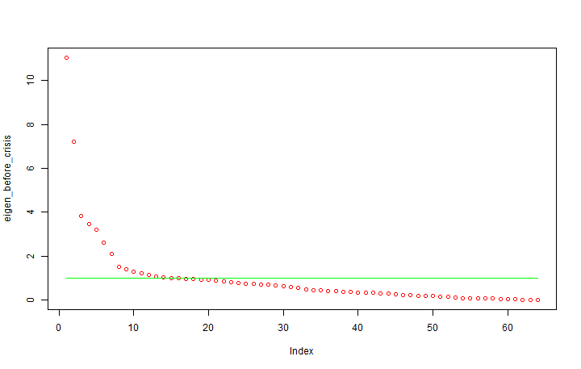

```r
before_crisis_data = futures_data[as.Date(rownames(futures_data)) < "2007-10-01",
    ]
before_crisis_components <- PCA(before_crisis_data, graph = FALSE)
before_crisis_table <- before_crisis_components$eig
colnames(before_crisis_table) <- c("Eigenvalue", "Pct of explained variance",
    "Cumulative pct of explained variance")
eigen_before_crisis <- before_crisis_table[, "Eigenvalue"]
plot(eigen_before_crisis, col = "red")
lines(rep(1, length(eigen_before_crisis)), col = "green")
```

Financial-crisis years:

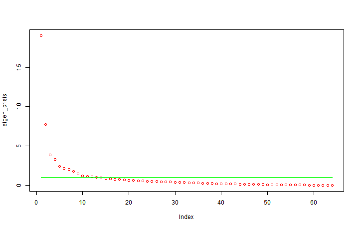

```r
crisis_data = futures_data[as.Date(rownames(futures_data)) > "2007-10-01" &
    as.Date(rownames(futures_data)) < "2009-03-01", ]
crisis_components <- PCA(crisis_data, graph = FALSE)
crisis_table <- crisis_components$eig
colnames(crisis_table) <- c("Eigenvalue", "Pct of explained variance", "Cumulative pct of explained variance")
eigen_crisis <- crisis_table[, "Eigenvalue"]
plot(eigen_crisis, col = "red")
lines(rep(1, length(eigen_crisis)), col = "green")
```

*5. Pre-crisis years:

```r
before_corused = cor(before_crisis_data[, apply(before_crisis_data != 0, 2,
    sum) > 10, drop = F])
Rotated_Results <- principal(before_corused, nfactors = 20, rotate = "varimax",
    score = TRUE)
Rotated_Factors <- round(Rotated_Results$loadings, 2)
Rotated_Factors <- as.data.frame(unclass(Rotated_Factors))
colnames(Rotated_Factors) <- paste("comp", 1:ncol(Rotated_Factors), sep = " ")

sorted_rows <- sort(Rotated_Factors[, 1], decreasing = TRUE, index.return = TRUE)$ix
Rotated_Factors <- Rotated_Factors[sorted_rows, ]
Rotated_Factors[abs(Rotated_Factors) < 0.3] <- NA
show_data_before <- Rotated_Factors
iprint.df(show_data_before, scale = TRUE)
```

<!--html_preserve-->

|  | comp 1 | comp 2 | comp 3 | comp 4 | comp 5 | comp 6 | comp 7 | comp 8 | comp 9 | comp 10 | comp 11 | comp 12 | comp 13 | comp 14 | comp 15 | comp 16 | comp 17 | comp 18 | comp 19 | comp 20 |
| --- | --- | --- | --- | --- | --- | --- | --- | --- | --- | --- | --- | --- | --- | --- | --- | --- | --- | --- | --- | --- |
| 5 yr T-Notes US | 0.93 |  |  |  |  |  |  |  |  |  |  |  |  |  |  |  |  |  |  |  |
| 10yr T-Notes | 0.93 |  |  |  |  |  |  |  |  |  |  |  |  |  |  |  |  |  |  |  |
| 2 yr T-Note US | 0.89 |  |  |  |  |  |  |  |  |  |  |  |  |  |  |  |  |  |  |  |
| Treasury Bonds | 0.88 |  |  |  |  |  |  |  |  |  |  |  |  |  |  |  |  |  |  |  |
| Eurodollar | 0.84 |  |  |  |  |  |  |  |  |  |  |  |  |  |  |  |  |  |  |  |
| Canadian Bond | 0.83 |  |  |  |  |  |  |  |  |  |  |  |  |  |  |  |  |  |  |  |
| Euro-Bund | 0.44 |  | 0.78 |  |  |  |  |  |  |  |  |  |  |  |  |  |  |  |  |  |
| Euro-Bobl | 0.43 |  | 0.82 |  |  |  |  |  |  |  |  |  |  |  |  |  |  |  |  |  |
| Euro-Schatz | 0.39 |  | 0.81 |  |  |  |  |  |  |  |  |  |  |  |  |  |  |  |  |  |
| Gilts UK | 0.33 |  | 0.75 |  |  |  |  |  |  |  |  |  |  |  |  |  |  |  |  |  |
| Euribor |  |  | 0.83 |  |  |  |  |  |  |  |  |  |  |  |  |  |  |  |  |  |
| Euroswiss |  |  | 0.70 |  |  |  |  |  |  |  |  |  |  |  |  |  |  |  |  |  |
| Swiss Franc |  | 0.81 |  |  |  |  |  |  |  |  |  |  |  |  |  |  |  |  |  |  |
| Euro |  | 0.86 |  |  |  |  |  |  |  |  |  |  |  |  |  |  |  |  |  |  |
| British Pound |  | 0.76 |  |  |  |  |  |  |  |  |  |  |  |  |  |  |  |  |  |  |
| Norwegian Krone |  | 0.80 |  |  |  |  |  |  |  |  |  |  |  |  |  |  |  |  |  |  |
| Japanese Yen |  | 0.37 |  |  |  |  |  |  |  |  |  | 0.74 |  |  |  |  |  |  |  |  |
| Gold |  | 0.47 |  |  |  |  |  |  | 0.57 |  |  |  |  |  |  |  |  |  |  |  |
| Gasoline |  |  |  |  | 0.41 |  |  |  | 0.30 |  |  |  |  |  |  |  |  |  |  |  |
| JGB Japan |  |  |  |  |  |  |  |  |  |  | 0.71 |  |  |  |  |  |  |  |  |  |
| Orange Juice |  |  |  |  |  |  |  |  |  |  |  |  |  |  |  |  |  | 0.91 |  |  |
| Silver |  | 0.37 |  | 0.31 |  |  |  |  | 0.62 |  |  |  |  |  |  |  |  |  |  |  |
| Canadian Dollar |  | -0.57 |  |  |  |  |  |  |  |  |  |  |  |  |  |  |  |  |  |  |
| Singapore Dollar |  | 0.46 |  |  |  |  |  |  |  |  |  | 0.70 |  |  |  |  |  |  |  |  |
| Sugar |  |  |  |  |  |  |  |  |  |  |  |  |  | 0.74 |  |  |  |  |  |  |
| Heating Oil |  |  |  |  | 0.92 |  |  |  |  |  |  |  |  |  |  |  |  |  |  |  |
| Kerosene |  |  |  |  |  |  |  |  |  |  |  |  |  |  | 0.86 |  |  |  |  |  |
| Australian Dollar |  | 0.78 |  |  |  |  |  |  |  |  |  |  |  |  |  |  |  |  |  |  |
| Soybeans |  |  |  |  |  | 0.92 |  |  |  |  |  |  |  |  |  |  |  |  |  |  |
| Soybean Oil |  |  |  |  |  | 0.81 |  |  |  |  |  |  |  |  |  |  |  |  |  |  |
| Natural Gas |  |  |  |  | 0.54 |  |  |  |  |  |  |  |  |  |  |  |  |  |  |  |
| Brent Crude |  |  |  |  | 0.91 |  |  |  |  |  |  |  |  |  |  |  |  |  |  |  |
| Corn |  |  |  |  |  | 0.69 |  |  |  |  |  |  |  |  |  |  |  |  |  |  |
| Soybean Meal |  |  |  |  |  | 0.81 |  |  |  |  |  |  |  |  |  |  |  |  |  |  |
| Crude Oil |  |  |  |  | 0.92 |  |  |  |  |  |  |  |  |  |  |  |  |  |  |  |
| New Zealand Dollar |  | 0.75 |  |  |  |  |  |  |  |  |  |  |  |  |  |  |  |  |  |  |
| Coffee |  |  |  |  |  |  |  |  |  |  |  |  |  | 0.52 |  | 0.40 |  |  |  |  |
| Canola |  |  |  |  |  | 0.78 |  |  |  |  |  |  |  |  |  |  |  |  |  |  |
| Gas Oil |  |  |  |  | 0.70 |  |  |  |  |  |  |  |  |  | 0.34 |  |  |  |  |  |
| Copper NY |  |  |  | 0.85 |  |  |  |  |  |  |  |  |  |  |  |  |  |  |  |  |
| Copper LDN |  |  |  | 0.90 |  |  |  |  |  |  |  |  |  |  |  |  |  |  |  |  |
| Platinum |  |  |  |  |  |  |  |  | 0.59 |  |  |  |  |  |  |  | -0.33 |  |  |  |
| Aluminium |  |  |  | 0.82 |  |  |  |  |  |  |  |  |  |  |  |  |  |  |  |  |
| Nickel |  |  |  | 0.70 |  |  |  |  |  |  |  |  |  |  |  |  |  |  |  |  |
| Euroyen |  |  |  |  |  |  |  |  |  |  | 0.82 |  |  |  |  |  |  |  |  |  |
| Wheat |  |  |  |  |  | 0.51 |  |  |  |  |  |  |  | 0.39 |  |  |  |  |  |  |
| Lean Hoggs |  |  |  |  |  |  |  |  |  |  |  |  |  |  |  |  |  |  |  | 0.95 |
| Russel 2000 E-Mini |  |  |  |  |  |  |  |  |  |  |  |  | 0.82 |  |  |  |  |  |  |  |
| Cocoa |  |  |  |  |  |  |  |  |  |  |  |  |  |  |  | 0.85 |  |  |  |  |
| Lumber |  |  |  |  |  |  |  |  |  |  |  |  |  |  |  |  |  |  | 0.94 |  |
| Zinc |  |  |  | 0.83 |  |  |  |  |  |  |  |  |  |  |  |  |  |  |  |  |
| Palladium |  |  |  |  |  |  |  |  | 0.68 |  |  |  |  |  |  |  |  |  |  |  |
| OMX 30 Stockholm |  |  |  |  |  |  | 0.36 |  |  |  |  |  | 0.56 |  |  |  |  |  |  |  |
| NIKKEI 225 |  |  |  |  |  |  |  |  |  | 0.80 |  |  |  |  |  |  |  |  |  |  |
| Hang Seng |  |  |  |  |  |  |  |  |  | 0.78 |  |  |  |  |  |  |  |  |  |  |
| TSE Toronto |  |  |  |  |  |  |  | 0.73 |  |  |  |  |  |  |  |  |  |  |  |  |
| Cotton |  |  |  |  |  |  |  |  |  |  |  |  |  |  |  |  | 0.73 |  |  |  |
| FTSE 100 UK |  |  |  |  |  |  | 0.83 |  |  |  |  |  |  |  |  |  |  |  |  |  |
| CAC 40 France |  |  |  |  |  |  | 0.85 |  |  |  |  |  |  |  |  |  |  |  |  |  |
| SP500 E-Mini |  |  |  |  |  |  |  | 0.90 |  |  |  |  |  |  |  |  |  |  |  |  |
| Eurostoxx |  |  |  |  |  |  | 0.83 | 0.37 |  |  |  |  |  |  |  |  |  |  |  |  |
| Dow Jones |  |  |  |  |  |  |  | 0.77 |  |  |  |  |  |  |  |  |  |  |  |  |
| Nasdaq 100 Mini |  |  |  |  |  |  |  | 0.85 |  |  |  |  |  |  |  |  |  |  |  |  |
| DAX 30 |  |  |  |  |  |  | 0.77 | 0.41 |  |  |  |  |  |  |  |  |  |  |  |  |

<!--/html_preserve-->

Financial-crisis years:

```r
crisis_corused = cor(crisis_data[, apply(crisis_data != 0, 2, sum) > 10, drop = F])
Rotated_Results <- principal(crisis_corused, nfactors = 20, rotate = "varimax",
    score = TRUE)
Rotated_Factors <- round(Rotated_Results$loadings, 2)
Rotated_Factors <- as.data.frame(unclass(Rotated_Factors))
colnames(Rotated_Factors) <- paste("comp", 1:ncol(Rotated_Factors), sep = " ")

sorted_rows <- sort(Rotated_Factors[, 1], decreasing = TRUE, index.return = TRUE)$ix
Rotated_Factors <- Rotated_Factors[sorted_rows, ]
Rotated_Factors[abs(Rotated_Factors) < 0.3] <- NA
show_data_crisis <- Rotated_Factors
iprint.df(show_data_crisis, scale = TRUE)
```

<!--html_preserve-->

|  | comp 1 | comp 2 | comp 3 | comp 4 | comp 5 | comp 6 | comp 7 | comp 8 | comp 9 | comp 10 | comp 11 | comp 12 | comp 13 | comp 14 | comp 15 | comp 16 | comp 17 | comp 18 | comp 19 | comp 20 |
| --- | --- | --- | --- | --- | --- | --- | --- | --- | --- | --- | --- | --- | --- | --- | --- | --- | --- | --- | --- | --- |
| 10yr T-Notes | 0.93 |  |  |  |  |  |  |  |  |  |  |  |  |  |  |  |  |  |  |  |
| 5 yr T-Notes US | 0.91 |  |  |  |  |  |  |  |  |  |  |  |  |  |  |  |  |  |  |  |
| Treasury Bonds | 0.85 |  |  |  |  |  |  |  |  |  |  |  |  |  |  |  |  |  |  |  |
| 2 yr T-Note US | 0.84 |  |  |  |  |  |  |  |  |  |  |  |  |  |  |  |  |  |  |  |
| Eurodollar | 0.78 |  |  |  |  |  |  |  |  |  |  |  |  |  |  |  |  |  |  | 0.33 |
| Canadian Bond | 0.72 |  |  |  |  |  |  |  |  |  |  |  |  |  |  |  |  |  |  |  |
| Japanese Yen | 0.38 |  |  |  | 0.31 | -0.33 |  |  |  |  |  |  |  | -0.50 |  |  |  |  |  |  |
| Euro-Bund | 0.37 |  |  |  | 0.75 |  |  |  |  |  |  |  |  |  |  |  |  |  |  | -0.37 |
| Euro-Bobl | 0.33 |  |  |  | 0.84 |  |  |  |  |  |  |  |  |  |  |  |  |  |  |  |
| Gilts UK | 0.33 |  |  |  | 0.64 |  |  |  |  |  |  |  |  |  |  |  |  |  |  | -0.43 |
| Euro-Schatz |  |  |  |  | 0.84 |  |  |  |  |  |  |  |  |  |  |  |  |  |  |  |
| Swiss Franc |  | 0.82 |  |  |  |  |  |  |  |  |  |  |  |  |  |  |  |  |  |  |
| Euroswiss |  |  |  |  | 0.74 |  |  |  |  |  |  |  |  |  |  |  |  |  |  |  |
| Euribor |  |  |  |  | 0.87 |  |  |  |  |  |  |  |  |  |  |  |  |  |  |  |
| Gold |  | 0.36 |  |  |  |  |  |  |  | 0.78 |  |  |  |  |  |  |  |  |  |  |
| Euro |  | 0.90 |  |  |  |  |  |  |  |  |  |  |  |  |  |  |  |  |  |  |
| JGB Japan |  |  |  |  |  |  |  |  |  |  |  | 0.83 |  |  |  |  |  |  |  |  |
| Canadian Dollar |  | -0.50 |  |  |  |  |  |  |  |  |  |  |  | -0.49 |  |  |  |  |  |  |
| Kerosene |  |  |  |  |  |  |  |  | 0.35 |  |  |  | 0.80 |  |  |  |  |  |  |  |
| Silver |  | 0.41 |  |  |  |  |  |  |  | 0.73 |  |  |  |  |  |  |  |  |  |  |
| NIKKEI 225 |  |  |  |  |  | 0.31 |  |  | 0.70 |  |  | -0.34 |  |  |  |  |  |  |  |  |
| Euroyen |  |  |  |  |  |  |  |  |  |  |  | 0.89 |  |  |  |  |  |  |  |  |
| British Pound |  | 0.63 |  |  |  |  |  |  |  |  |  |  |  | 0.38 |  |  |  |  |  |  |
| Palladium |  |  |  |  |  |  |  |  |  | 0.57 |  |  |  |  |  | 0.34 |  |  |  |  |
| Zinc |  |  |  |  |  |  |  | 0.79 |  |  |  |  |  |  |  |  |  |  |  |  |
| Sugar |  |  |  |  |  |  |  |  |  |  | 0.65 |  |  |  |  |  |  |  |  |  |
| Cotton |  |  | 0.38 |  |  |  |  |  |  |  | 0.50 |  |  |  |  |  |  |  |  |  |
| Natural Gas |  |  |  |  |  |  |  |  |  |  |  |  |  |  |  |  |  |  | 0.89 |  |
| Coffee |  |  | 0.31 |  |  |  |  |  |  |  | 0.70 |  |  |  |  |  |  |  |  |  |
| Cocoa |  | 0.35 |  |  |  |  |  |  |  |  | 0.44 |  |  |  |  |  |  |  |  | 0.34 |
| Hang Seng |  |  |  |  |  |  |  |  | 0.76 |  |  |  |  |  |  |  |  |  |  |  |
| Singapore Dollar |  | 0.72 |  |  |  |  |  |  |  |  |  |  |  |  |  |  |  |  |  |  |
| Corn |  |  | 0.72 |  |  |  |  |  |  |  |  |  |  |  |  |  |  |  |  |  |
| Aluminium |  |  |  |  |  |  |  | 0.70 |  |  |  |  |  |  |  |  |  |  |  |  |
| Orange Juice |  |  |  |  |  |  |  |  |  |  |  |  |  |  |  |  |  | 0.96 |  |  |
| Gas Oil |  |  |  |  |  |  | 0.49 |  |  |  |  |  | 0.57 |  |  |  |  |  |  |  |
| Soybean Meal |  |  | 0.88 |  |  |  |  |  |  |  |  |  |  |  |  |  |  |  |  |  |
| Lean Hoggs |  |  |  |  |  |  |  |  |  |  |  |  |  |  |  |  | 0.92 |  |  |  |
| Brent Crude |  |  |  |  |  |  | 0.86 |  |  |  |  |  |  |  |  |  |  |  |  |  |
| Platinum |  |  |  |  |  |  |  |  |  |  |  |  |  |  |  | 0.84 |  |  |  |  |
| New Zealand Dollar |  | 0.63 |  |  |  |  |  |  |  |  |  |  |  | 0.35 |  |  |  |  |  |  |
| Soybeans |  |  | 0.88 |  |  |  |  |  |  |  |  |  |  |  |  |  |  |  |  |  |
| Canola |  |  | 0.79 |  |  |  |  |  |  |  |  |  |  |  |  |  |  |  |  |  |
| Copper LDN |  |  |  |  |  |  |  | 0.77 |  |  |  |  |  |  |  |  |  |  |  |  |
| Soybean Oil |  |  | 0.72 |  |  |  | 0.36 |  |  |  |  |  |  |  |  |  |  |  |  |  |
| Heating Oil |  |  |  |  |  |  | 0.84 |  |  |  |  |  |  |  |  |  |  |  |  |  |
| Gasoline |  |  |  |  |  |  | 0.84 |  |  |  |  |  |  |  |  |  |  |  |  |  |
| Wheat |  |  | 0.60 |  |  |  |  |  |  |  |  |  |  |  |  |  |  |  |  |  |
| Copper NY |  |  |  |  |  |  |  | 0.72 |  |  |  |  |  |  |  |  |  |  |  |  |
| Norwegian Krone |  | 0.78 |  |  |  |  |  |  |  |  |  |  |  |  |  |  |  |  |  |  |
| Australian Dollar |  | 0.54 |  |  |  | 0.32 |  |  | 0.34 |  |  |  |  |  |  |  |  |  |  |  |
| Nickel |  |  |  |  |  |  |  | 0.71 |  |  |  |  |  |  |  |  |  |  |  |  |
| Lumber |  |  |  |  |  |  |  |  |  |  |  |  |  |  | 0.91 |  |  |  |  |  |
| DAX 30 |  |  |  | 0.35 |  | 0.79 |  |  |  |  |  |  |  |  |  |  |  |  |  |  |
| Eurostoxx |  |  |  |  |  | 0.82 |  |  |  |  |  |  |  |  |  |  |  |  |  |  |
| FTSE 100 UK |  |  |  |  |  | 0.78 |  |  |  |  |  |  |  |  |  |  |  |  |  |  |
| OMX 30 Stockholm |  |  |  | 0.31 |  | 0.76 |  |  |  |  |  |  |  |  |  |  |  |  |  |  |
| CAC 40 France |  |  |  |  |  | 0.80 |  |  |  |  |  |  |  |  |  |  |  |  |  |  |
| Crude Oil |  |  |  |  |  |  | 0.82 |  |  |  |  |  |  |  |  |  |  |  |  |  |
| TSE Toronto |  |  |  | 0.70 |  |  |  |  |  |  |  |  |  |  |  |  |  |  |  |  |
| Dow Jones |  |  |  | 0.91 |  |  |  |  |  |  |  |  |  |  |  |  |  |  |  |  |
| Russel 2000 E-Mini |  |  |  | 0.90 |  |  |  |  |  |  |  |  |  |  |  |  |  |  |  |  |
| SP500 E-Mini |  |  |  | 0.90 |  |  |  |  |  |  |  |  |  |  |  |  |  |  |  |  |
| Nasdaq 100 Mini |  |  |  | 0.89 |  |  |  |  |  |  |  |  |  |  |  |  |  |  |  |  |

<!--/html_preserve-->

Components weigths are quite stable in both periods, even though returns look more correlated during crisis. In general commodities tend to be correlated in the same way before and during the crisis.

* * * * *

# A Simple Futures Trend Following Strategy

We can now develop a simple futures trend following trading strategy, as outlined in the papers in the Exercise Introduction above. There are about $300 billion invested in such strategies! Of course we cannot develop here a sophisticated product, but with some more work...

We will do the following:

1. Calculate a number of moving averages of different "window lengths" for each of the 64 futures - there are [many](http://www.r-bloggers.com/stock-analysis-using-r/) so called [technical indicators](http://www.investopedia.com/active-trading/technical-indicators/) one can use. We will use the "moving average" function `ma` for this (try for example to see what this returns `ma(1:10,2)` ).
2. Add the signs (can also use the actual moving average values of course - try it!) of these moving averages (as if they "vote"), and then scale this sum across all futures so that the sum of their (of the sum across all futures!) absolute value across all futures is 1 (hence we invest $1 every day - you see why?).
3. Then invest every day in each of the 64 an amount that is defined by the weights calculated in step 2, using however the weights calculated using data until 2 days ago (why 2 days and not 1 day?) - see the use of the helper function `shift` for this.
4. Finally see the performance of this strategy.

Here is the code:

```r
signal_used = 0 * futures_data  # just initialize the trading signal to be 0
# Take many moving Average (MA) Signals and let them 'vote' with their sign
# (+-1, e.g. long or short vote, for each signal)
MAfreq <- seq(10, 250, by = 20)
for (iter in 1:length(MAfreq)) signal_used = signal_used + sign(apply(futures_data,
    2, function(r) ma(r, MAfreq[iter])))
# Now make sure we invest $1 every day (so the sum of the absolute values of
# the weights is 1 every day)
signal_used = t(apply(signal_used, 1, function(r) {
    res = r
    if (sum(abs(r)) != 0)
        res = r/sum(abs(r))
    res
}))
colnames(signal_used) <- colnames(futures_data)
# Now create the returns of the strategy for each futures time series
strategy_by_future <- scrub(shift(signal_used, 2) * futures_data)  # signal 2 days ago
# finally, this is our futures trend following strategy
trading_strategy = apply(strategy_by_future, 1, sum)
names(trading_strategy) <- rownames(futures_data)
```

# Reporting the performance results

[output not shown]

Here is how this strategy has performed during this period:

<!--html_preserve-->

|  | Jan | Feb | Mar | Apr | May | Jun | Jul | Aug | Sep | Oct | Nov | Dec | Year |
| --- | --- | --- | --- | --- | --- | --- | --- | --- | --- | --- | --- | --- | --- |
| 2001 | 0.61 | 1.55 | 1.81 | -2.00 | 0.54 | 0.69 | 0.75 | 1.35 | 4.30 | 0.33 | -2.26 | -2.45 | 5.13 |
| 2002 | 0.20 | -0.44 | -2.61 | 1.01 | 0.39 | 1.72 | 2.06 | 1.65 | 3.38 | -2.50 | -1.27 | 3.07 | 6.64 |
| 2003 | 2.39 | 3.37 | -2.85 | -0.92 | 1.25 | -1.25 | 0.73 | -0.13 | -0.33 | 4.23 | 0.10 | 3.10 | 9.86 |
| 2004 | 1.22 | 3.16 | 0.06 | -1.66 | -0.13 | -1.40 | 3.00 | -2.75 | 4.36 | -0.77 | 0.98 | -0.07 | 5.91 |
| 2005 | -0.55 | 1.03 | 0.27 | -2.03 | -0.27 | 0.84 | 0.42 | 1.51 | 0.25 | -1.05 | 2.17 | 0.30 | 2.86 |
| 2006 | 2.00 | -0.87 | 2.05 | 3.85 | -0.30 | -1.63 | -0.76 | 0.00 | 0.60 | 2.23 | 0.50 | 1.17 | 9.05 |
| 2007 | 0.13 | -0.52 | -0.96 | 1.69 | 0.01 | 0.77 | -0.90 | -1.28 | 3.15 | 1.81 | -0.05 | 1.98 | 5.88 |
| 2008 | 2.52 | 5.71 | -3.06 | 0.36 | 2.38 | 4.06 | -4.41 | -1.66 | 5.35 | 14.30 | 3.88 | 1.61 | 34.20 |
| 2009 | 1.23 | 2.07 | -5.43 | -2.20 | -0.82 | -0.93 | 1.92 | 3.00 | 0.12 | 0.39 | 2.02 | 0.91 | 2.01 |
| 2010 | -3.39 | 0.19 | 3.88 | 1.10 | -5.04 | -2.45 | -1.27 | 0.01 | 2.31 | 3.59 | -1.06 | 6.41 | 3.75 |
| 2011 | 1.27 | 2.48 | -1.58 | 2.63 | -4.07 | -2.15 | 0.58 | -0.77 | 1.23 | -4.67 | 0.63 | -0.38 | -5.01 |
| 2012 | -0.94 | 0.20 | 0.34 | -0.12 | 1.57 | -1.80 | 1.35 | -0.33 | -0.74 | -0.92 | -0.36 | 0.13 | -1.65 |
| 2013 | 1.29 | -0.58 | 1.07 | 0.15 | 1.29 | 0.52 | 0.51 | -0.72 | 0.14 | 0.42 | 1.29 | 0.44 | 5.96 |
| 2014 | -1.12 | 0.80 | -0.11 | 0.54 | -0.41 | -0.16 | 0.69 | 0.96 | 0.89 | 0.52 | 2.53 | 2.64 | 7.98 |
| 2015 | 1.77 | -0.73 | 1.63 | -2.32 | 0.39 | -0.43 | 1.50 | -1.70 | 1.17 |  |  |  | 1.18 |

<!--/html_preserve-->

How does this compare with **existing CTA products** such as [this one from Societe Generale?](https://cib.societegenerale.com/fileadmin/indices_feeds/SG_CTA_Monthly_Report.pdf) (Note: one can easily achieve a correlation of more than 0.8 with this specific product - as well as with many other ones)

[figure not shown]

**Questions**

1. Can you describe in more detail what the code above does?
2. What happens if you use different moving average technical indicators in the code above? Please explore and report below the returns of a trading strategy you build. (Hint: check that the command line `MAfreq<-seq(10,250,by=20)` above does for example - but not only of course, the possibilities are endless)

**Answers**

```r
signal_used = 0 * futures_data  # just initialize the trading signal to be 0
# Take many moving Average (MA) Signals and let them 'vote' with their sign
# (+-1, e.g. long or short vote, for each signal)
MAfreq <- seq(10, 250, by = 20)
for (iter in 1:length(MAfreq)) signal_used = signal_used + apply(futures_data,
    2, function(r) WMA(r, MAfreq[iter], wts = 1:MAfreq[iter]))
# Now make sure we invest $1 every day (so the sum of the absolute values of
# the weights is 1 every day)
signal_used[is.na(signal_used)] <- 0
signal_used = t(apply(signal_used, 1, function(r) {
    res = r
    if (sum(abs(r)) != 0)
        res = r/sum(abs(r))
    res
}))
colnames(signal_used) <- colnames(futures_data)
# Now create the returns of the strategy for each futures time series
strategy_by_future <- scrub(shift(signal_used, 2) * futures_data)  # signal 2 days ago
# finally, this is our futures trend following strategy
trading_strategy2 = apply(strategy_by_future, 1, sum)
names(trading_strategy2) <- rownames(futures_data)

iplot.pnl(trading_strategy2)
```

[output not shown]

* * * * * * * *

# A class competition

Now you have seen how to develop some trading strategies that hedge funds have been using for centuries. Clearly this is only the very first step - as many of the online resources on technical indicators also suggest. Can you now explore more such strategies? How good a **futures trend following hedge fund strategy** can you develop? Let's call this.... a **class competition**! Explore as much as you can and report your best strategy as we move along the course...

Here is for example something that can be achieved relatively easily...

[output not shown]

Here is how this strategy has performed during this period:

<!--html_preserve-->

|  | Jan | Feb | Mar | Apr | May | Jun | Jul | Aug | Sep | Oct | Nov | Dec | Year |
| --- | --- | --- | --- | --- | --- | --- | --- | --- | --- | --- | --- | --- | --- |
| 2001 | 0.00 | 0.00 | 0.68 | -1.00 | 0.02 | -0.05 | 0.60 | 0.95 | 2.41 | 1.25 | -2.21 | -0.98 | 1.59 |
| 2002 | -0.56 | -0.18 | -0.81 | 0.21 | 1.09 | 1.92 | 1.85 | 1.25 | 1.75 | -0.93 | -0.68 | 2.76 | 7.85 |
| 2003 | 1.33 | 1.53 | -0.83 | 0.12 | 1.86 | -0.90 | -0.31 | -0.20 | -0.03 | 1.98 | 0.09 | 1.82 | 6.58 |
| 2004 | 0.76 | 1.90 | -0.07 | -1.83 | -0.19 | -0.32 | 0.33 | -1.02 | 1.32 | 0.19 | 1.33 | 0.26 | 2.62 |
| 2005 | -0.36 | 0.37 | 0.02 | -0.70 | 0.51 | 0.93 | 0.13 | 0.17 | 0.69 | -0.04 | 1.55 | 0.41 | 3.72 |
| 2006 | 1.21 | -0.04 | 2.10 | 2.03 | -0.42 | -0.17 | -0.89 | -0.54 | -0.15 | 0.95 | 0.71 | 0.73 | 5.61 |
| 2007 | 0.39 | -0.98 | -0.08 | 1.70 | 1.18 | 1.33 | -1.27 | -2.41 | 2.01 | 1.11 | 0.29 | 0.67 | 3.92 |
| 2008 | 2.60 | 2.96 | -0.98 | -0.37 | 0.69 | 1.68 | -1.97 | -0.14 | 1.78 | 4.35 | 1.62 | 0.73 | 13.57 |
| 2009 | 0.05 | 0.72 | -1.36 | -1.15 | 0.41 | -0.73 | 0.88 | 0.83 | 0.71 | -0.14 | 1.64 | -0.63 | 1.19 |
| 2010 | -1.26 | 0.47 | 1.34 | 0.77 | -1.30 | -0.49 | -0.45 | 1.10 | 1.04 | 1.67 | -0.89 | 2.38 | 4.38 |
| 2011 | 0.58 | 1.16 | -0.69 | 1.74 | -1.71 | -1.50 | 0.98 | 0.64 | 0.81 | -1.86 | 0.46 | 0.39 | 0.93 |
| 2012 | -0.29 | -0.15 | -0.05 | -0.10 | 1.27 | -1.08 | 0.66 | -0.25 | -0.22 | -0.77 | -0.18 | -0.13 | -1.31 |
| 2013 | 1.09 | -0.98 | 0.82 | -0.03 | 0.72 | 0.85 | 0.20 | -0.26 | 0.12 | 0.23 | 0.90 | 1.01 | 4.73 |
| 2014 | -1.33 | 0.46 | -0.12 | 0.06 | 0.32 | 0.42 | 0.01 | 1.15 | 1.85 | 0.68 | 2.07 | 1.49 | 7.24 |
| 2015 | 2.17 | -0.30 | 1.10 | -1.49 | 0.27 | 0.04 | 0.40 | -0.77 | 0.73 |  |  |  | 2.11 |

<!--/html_preserve-->

As always, **have fun**